# Reconhecimento de imagens com face recognition, openCV e numpy

#### Para esse projeto também foi usado o matplotlib para apresentação das imagens

- Esse estudo foi desenvolvido usando o Google Colab
1. Primeiro instalamos a face_recognition

```python
!pip3 install face_recognition
```

```
     |████████████████████████████████| 100.1 MB 9.0 kB/s
```

1. Importamos as bibliotecas

```python
import cv2
import numpy as np
import face_recognition
import matplotlib.pyplot as plt
```

1. importamos as fotos
   - Estou usando 3 fotos minhas
   - Uma de uma garota (Maria Helena)
   - Uma da minha equipe de programação competitiva

```python
luis = cv2.cvtColor(cv2.imread('pp.jpeg'), cv2.COLOR_BGR2RGB)
luis2 = cv2.cvtColor(cv2.imread('luis2.jpeg'), cv2.COLOR_BGR2RGB)
luis3 = cv2.cvtColor(cv2.imread('luis3.jpg'), cv2.COLOR_BGR2RGB)
maria = cv2.cvtColor(cv2.imread('maria.jpeg'), cv2.COLOR_BGR2RGB)
jaci = cv2.cvtColor(cv2.imread('saci.jpeg'), cv2.COLOR_BGR2RGB)
```

1. Nessa parte eu desenvolvo uma função que recebe as fotos e apresenta usando matplotlib

```python
def show_img(img):
  if type(img) is list:
    tam = len(img)
    if tam % 3 == 0:
      lin, col = tam//3, 3
    elif tam < 3:
      lin, col = 1, tam
    else:
      lin, col = (tam//3) + 1, 3
    fig, axes = plt.subplots(lin, col)
    for i in range(lin):
      for j in range(col):
        if lin != 1:
          axes[i, j].imshow(img[tam-1])
          axes[i, j].axis('off')
        else:
          axes[j].imshow(img[tam-1])
          axes[j].axis('off')
        tam -= 1
  else:
    plt.imshow(img)
  plt.axis('off')
  plt.show()
```

1. Testando a função
   - Sou lindo
   - Minha prima também
   - Minha equipe é TOP

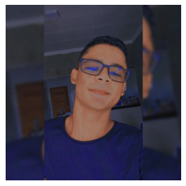

```python
show_img(luis)
```

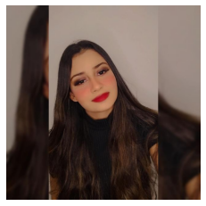

```python
show_img(maria)
```

[figure not shown]

```python
show_img(jaci)
```

1. verifico o conteúdo da variável (luis)
   - Como pode ser analisado uma imagem é apenas um array

```python
luis
```

```
array([[[54, 55, 76],
        [54, 55, 76],
        [54, 55, 75],
        ...,
        [29, 33, 44],
        [29, 33, 44],
        [29, 33, 44]],

       [[54, 55, 76],
        [54, 55, 76],
        [54, 55, 75],
        ...,
        [29, 33, 44],
        [29, 33, 44],
        [29, 33, 44]],

       [[54, 55, 76],
        [54, 55, 76],
        [54, 55, 75],
        ...,
        [29, 33, 44],
        [29, 33, 44],
        [29, 33, 44]],

       ...,

       [[31, 31, 81],
        [31, 31, 81],
        [31, 31, 81],
        ...,
        [22, 24, 62],
        [22, 24, 62],
        [22, 24, 62]],

       [[31, 31, 81],
        [31, 31, 81],
        [31, 31, 81],
        ...,
        [22, 24, 62],
        [22, 24, 62],
        [22, 24, 62]],

       [[31, 31, 81],
        [31, 31, 81],
        [31, 31, 81],
        ...,
        [22, 24, 62],
        [22, 24, 62],
        [22, 24, 62]]], dtype=uint8)
```

1. Pegando as posições do meu rosto na foto
   - Ele devolve um array com a posição de todas as fotos encontradas e como sei que só tem a minha peguei logo a primeira encontrada
   - O modelo de busca padrão é "hog" que não é dos mais eficientes mas você pode mudar para "cnn" que é um modelo que usa deep-learning porém ele precisa de GPU para ser acelerado

```python
top_luis, right_luis, botton_luis, left_luis = face_recognition.face_locations(luis)[0]
```

```python
luis_face = luis[top_luis:botton_luis, left_luis:right_luis]
```

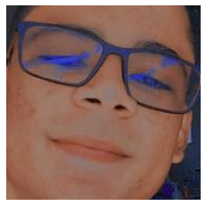

```python
show_img(luis_face)
```

```python
jaci_faces = [jaci[pessoa[0]:pessoa[2], pessoa[3]:pessoa[1]] for pessoa in face_recognition.face_locations(jaci,model='cnn')]
jaci_faces
```

[output not shown]

[output cut: 90 more lines]

[output not shown]

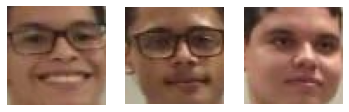

```python
show_img(jaci_faces)
```

1. O método face encodings devolve um vetor de 128 dimenções para pontos do rosto
   - Existem bibliotecas que trabalham com mais posições

```python
luis_encoding = face_recognition.face_encodings(luis)
```

```python
maria_encoding = face_recognition.face_encodings(maria)
```

```python
jaci_encoding = face_recognition.face_encodings(jaci)
```

```python
jaci_encoding
```

[output not shown]

[output cut: 29 more lines]

[output not shown]

1. Aqui temos o método mais aguardado, o compare_faces literalmente compara uma lista de rostos com um único rosto e retorna uma lista com os rostos compatíveis com o rosto comparado

```python
is_luis = face_recognition.compare_faces(maria_encoding, luis_encoding[0])
is_luis
```

```
[False]
```

```python
luis_and_maria_distance = face_recognition.face_distance(maria_encoding, luis_encoding[0])
luis_and_maria_distance
```

```
array([0.78939632])
```

1. Procurando meu rosto na minha equipe

```python
luis_esta = face_recognition.compare_faces(jaci_encoding, luis_encoding[0])
luis_esta
```

```
[False, True, False]
```

- Indentificou que estou presente na foto
- Agora vamos ver se acertou

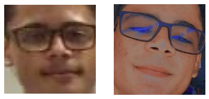

```python
for i, comp in enumerate(luis_esta):
  if comp:
    show_img([luis_face, jaci_faces[i]])
```

1. Verificando a distância entre meu rosto nas fotos enviadas ao compare_face

```python
face_recognition.face_distance(luis_encoding, jaci_encoding[1])
```

```
array([0.56834275])
```

1. Verificando mais uma vez

```python
luis2_encoding = face_recognition.face_encodings(luis2)
```

```python
is_luis = face_recognition.compare_faces(luis_encoding, luis2_encoding[0])
```

```python
is_luis
```

```
[True]
```

```python
top_luis2, right_luis2, botton_luis2, left_luis2 = face_recognition.face_locations(luis2, model='cnn')[0]
luis2_face = luis2[top_luis2:botton_luis2, left_luis2:right_luis2]
```

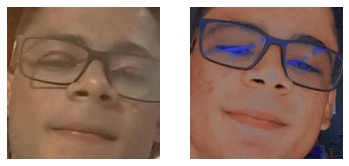

```python
for i, comp in enumerate(is_luis):
  if comp:
    show_img([luis_face, luis2_face])
```

1. Testando mais uma vez com uma foto um pouco mais antiga

```python
luis3_encoding = face_recognition.face_encodings(luis3)
```

```python
luis_denovo = face_recognition.compare_faces(luis_encoding, luis3_encoding[0])
luis_denovo
```

```
[True]
```

```python
top_luis3, right_luis3, botton_luis3, left_luis3 = face_recognition.face_locations(luis3, model='cnn')[0]
luis3_face = luis3[top_luis3:botton_luis3, left_luis3:right_luis3]
```

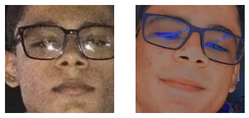

```python
for i, comp in enumerate(is_luis):
  if comp:
    show_img([luis_face, luis3_face])
```

1. O face_landmarks retorna os pontos indentificados do seu rosto em um dicionário

```python
landmark_luis = face_recognition.face_landmarks(luis_face)[0]
landmark_luis
```

```
{'bottom_lip': [(116, 146),
  (103, 149),
  (90, 147),
  (80, 145),
  (72, 143),
  (58, 140),
  (42, 131),
  (49, 132),
  (75, 134),
  (83, 135),
  (92, 137),
  (111, 144)],
 'chin': [(1, 56),
  (-1, 78),
  (-1, 100),
  (-2, 123),
  (-1, 145),
  (7, 165),
  (23, 178),
  (44, 185),
  (71, 188),
  (97, 188),
  (119, 184),
  (138, 176),
  (151, 165),
  (160, 148),
  (166, 130),
  (171, 111),
  (176, 92)],
 'left_eye': [(38, 46), (49, 40), (60, 41), (70, 49), (59, 50), (48, 49)],
 'left_eyebrow': [(20, 29), (34, 16), (54, 12), (74, 15), (91, 25)],
 'nose_bridge': [(102, 44), (102, 55), (101, 66), (100, 77)],
 'nose_tip': [(73, 94), (83, 98), (93, 102), (103, 102), (111, 100)],
 'right_eye': [(122, 56),
  (133, 51),
  (145, 54),
  (152, 63),
  (143, 64),
  (132, 61)],
 'right_eyebrow': [(120, 29), (137, 26), (153, 28), (167, 37), (172, 53)],
 'top_lip': [(42, 131),
  (62, 127),
  (78, 125),
  (86, 129),
  (95, 129),
  (106, 136),
  (116, 146),
  (111, 144),
  (93, 138),
  (84, 137),
  (76, 134),
  (49, 132)]}
```

1. Inserindo micro pontos nas marcações da face landmark para ver os pricipais pontos do meu rosto para a biblioteca

```python
for mark in landmark_luis.keys():
  for point in landmark_luis[mark]:
    cv2.circle(luis_face, point, 1, (0, 255, 0), -1)
```

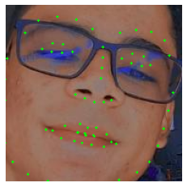

```python
show_img(luis_face)
```

### Essa biblioteca é bem simples mas muito eficiente e ótima para quem está iniciando assim como eu

#### By Luis Henrique

- [GitHub](https://github.com/LuisHenrique01)
- [Linkedin](https://www.linkedin.com/in/luis-henrique-b-aa8669136/)
- [Instagram](https://www.instagram.com/luis_h_bueno.py/)